# dijkstra

## Algorytm Dijkstry

Mając dany graf z wyróżnionym wierzchołkiem (źródłem) algorytm znajduje odległości od źródła do wszystkich pozostałych wierzchołków. Łatwo zmodyfikować go tak, aby szukał wyłącznie (najkrótszej) ścieżki do jednego ustalonego wierzchołka, po prostu przerywając działanie w momencie dojścia do wierzchołka docelowego.

Algorytm Dijkstry znajduje w grafie wszystkie najkrótsze ścieżki pomiędzy wybranym wierzchołkiem a wszystkimi pozostałymi, przy okazji wyliczając również koszt przejścia każdej z tych ścieżek.

### Zasada działania (pierwsze kroki):

Mamy graf nieskierowany G=(V,E,W), gdzie:

V: zbiór wierzchołków grafu  
V={ A,B,C,D,E,F,G,H,I,J,K,M,N,O,P,R,S,T,U,V,W,X,Y,Z }

E: zbiór krawędzi grafu  
E={(A,B),(A,G),(G,E),(D,E),(C,D),(C,E),(B,C),(G,I),(G,H),(H,I), (F,H),(E,F),(F,S),(D,S),(S,U),(R,S),(N,R),(P,R),(N,P),(K,N), (K,M),(F,M),(I,M),(I,J),(J,K),(K,O),(O,P),(P,T),(R,T),(T,U), (U,W),(P,W),(P,V),(V,W),(W,X),(V,X),(X,Z),(Y,Z),(J,Y),(O,Y),(M,N),(V,Z)}

W: zbiór wag na krawędziach grafu  
W={(104),(88,6),(82,5),(26,2),(32,3),(40,3),(32,6),(49,7),(43,9),(37,8), (21,5),(53,1),(70,7),(65,5),(72,2),(52),(30,2),(26,3),(36,8),(18,3), (8),(63,9),(43,9),(50,6),(25),(50,5),(44,6),(26,6),(18,3),(21,9), (15,9),(60,3),(35,8),(36,8),(98,8),(68,3),(15,7),(29,9),(183),(81,9),(38,3),(82,8)}

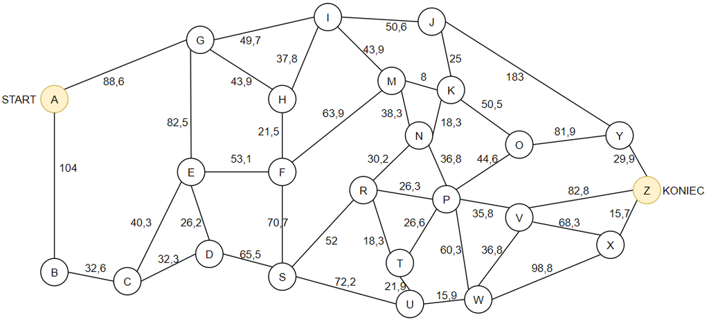

Zanim zaczniemy przypiszmy wierzchołkom pewne wartości liczbowe. Startowemu wartość 0, reszcie nieskończoność.

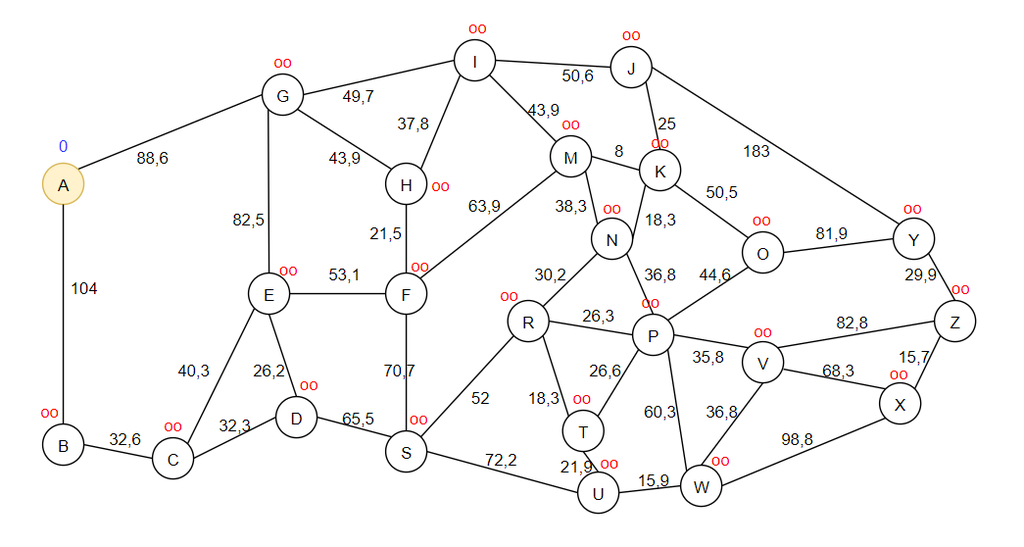

Zaczynamy od wierzchołka A. Znajdujemy ścieżki sąsiadujące z naszym wierzchołkiem. Każda ścieżka (krawędź) ma swoją wagę. Wartość tych wag wpisujemy nad wierzchołkami, z którymi jest połączony dany wierzchołek.

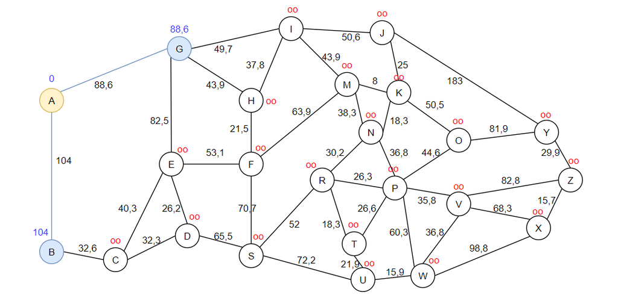

Teraz wybieramy najmniejszą wartość z tych wpisanych nad wierzchołkami.

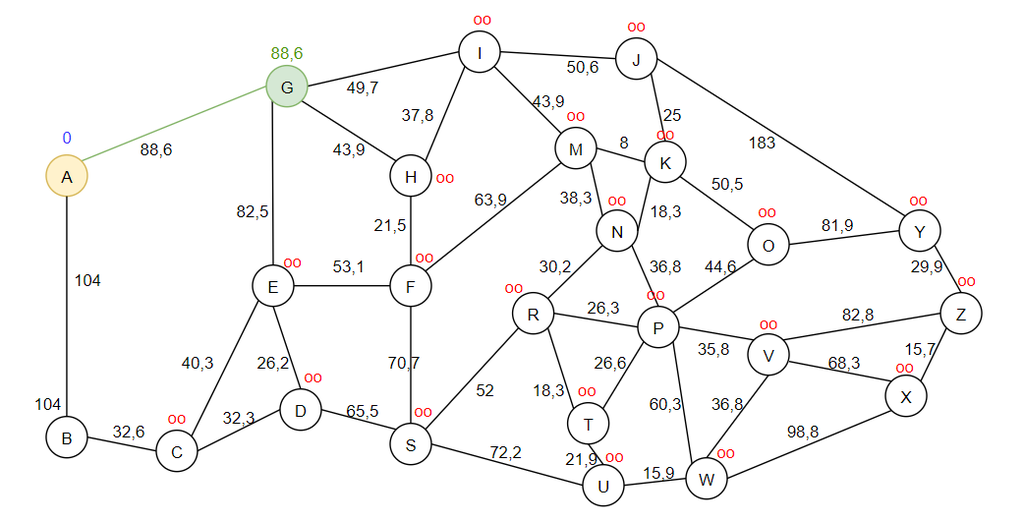

I na koniec przechodzimy do nowego wierzchołka (w tym przypadku jest to wierzchołek G) oraz zaznaczamy wierzchołek A jako "odwiedzony"

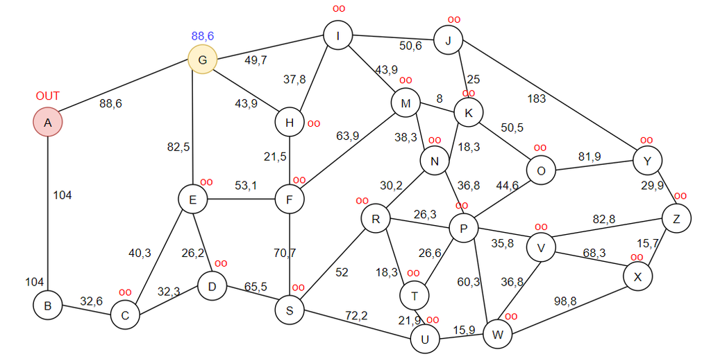

Teraz powtarzamy całą analogię z małą różnicą. Gdy mamy już jakąś wartość nad wierzchołkiem, to zamiast przepisywać wagę z krawędzi na sąsiadujący wierzchołek, to dodajemy wartości (wartość nad wierzchołkiem + waga krawędzi).

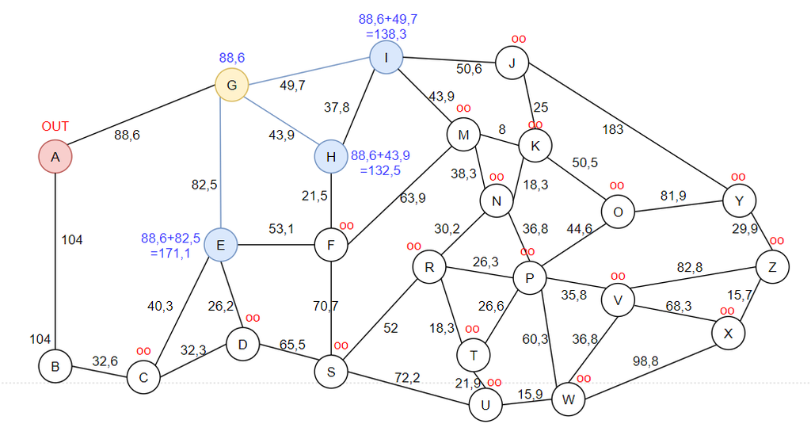

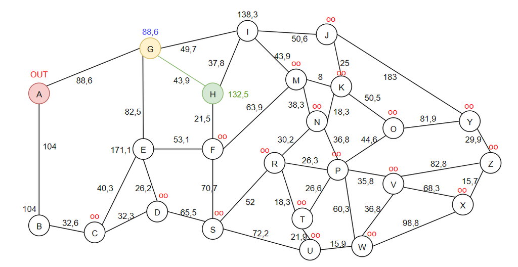

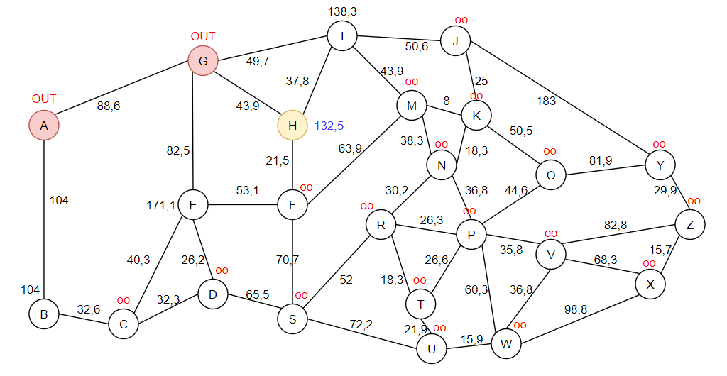

Poniżej zaznaczono najkrótszą ścieżkę dla podanych danych:

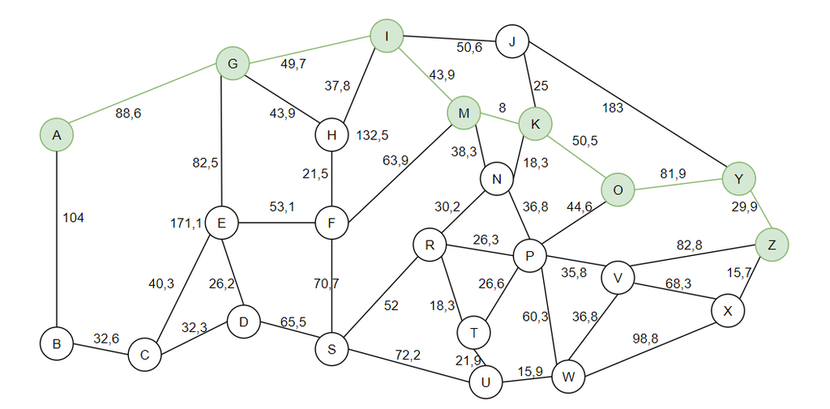

Teraz pora napisać algorytm, który wyliczy nam tę najkrótszą ścieżkę.

### Implementacja algorytmu

#### Dane

```python
nodes = ('A','B','C','D','E','F','G','H','I','J','K','M','N','O','P','R','S','T','U','V','W','X','Y','Z')
edges = [('A','B'),('A','G'),('G','E'),('D','E'),('C','D'),('C','E'),('B','C'),('G','I'),('G','H'),('H','I'), ('F','H'),('E','F'),('F','S'),('D','S'),('S','U'),('R','S'),('N','R'),('P','R'),('N','P'),('K','N'),('K','M'),('F','M'),('I','M'),('I','J'),('J','K'),('K','O'),('O','P'),('P','T'),('R','T'),('T','U'),('U','W'),('P','W'),('P','V'),('V','W'),('W','X'),('V','X'),('X','Z'),('Y','Z'),('J','Y'),('O','Y'),('M','N'),('V','Z')]
distances = (104,88.6,82.5,26.2,32.3,40.3,32.6,49.7,43.9,37.8,21.5,53.1,70.7,65.5,72.2,52,30.2,26.3,36.8,18.3,8,63.9,43.9,50.6,25,50.5,44.6,26.6,18.3,21.9,15.9,60.3,35.8,36.8,98.8,68.3,15.7,29.9,183,81.9,38.3,82.8)
```

#### Budowanie grafu

Podanie wszystkich wierzchołków, które można odwiedzić z innego wierzchołka w słowniku wraz z ich odległościami

```python
def get_graph():
    graph = {}
    for node in nodes:
        graph[node] = {}
        for index, (A, B) in enumerate(edges):
            if node == A:
                graph[node][B] = distances[index]
            elif node == B:
                graph[node][A] = distances[index]

    return graph
get_graph()
```

```
{'A': {'B': 104, 'G': 88.6},
 'B': {'A': 104, 'C': 32.6},
 'C': {'D': 32.3, 'E': 40.3, 'B': 32.6},
 'D': {'E': 26.2, 'C': 32.3, 'S': 65.5},
 'E': {'G': 82.5, 'D': 26.2, 'C': 40.3, 'F': 53.1},
 'F': {'H': 21.5, 'E': 53.1, 'S': 70.7, 'M': 63.9},
 'G': {'A': 88.6, 'E': 82.5, 'I': 49.7, 'H': 43.9},
 'H': {'G': 43.9, 'I': 37.8, 'F': 21.5},
 'I': {'G': 49.7, 'H': 37.8, 'M': 43.9, 'J': 50.6},
 'J': {'I': 50.6, 'K': 25, 'Y': 183},
 'K': {'N': 18.3, 'M': 8, 'J': 25, 'O': 50.5},
 'M': {'K': 8, 'F': 63.9, 'I': 43.9, 'N': 38.3},
 'N': {'R': 30.2, 'P': 36.8, 'K': 18.3, 'M': 38.3},
 'O': {'K': 50.5, 'P': 44.6, 'Y': 81.9},
 'P': {'R': 26.3, 'N': 36.8, 'O': 44.6, 'T': 26.6, 'W': 60.3, 'V': 35.8},
 'R': {'S': 52, 'N': 30.2, 'P': 26.3, 'T': 18.3},
 'S': {'F': 70.7, 'D': 65.5, 'U': 72.2, 'R': 52},
 'T': {'P': 26.6, 'R': 18.3, 'U': 21.9},
 'U': {'S': 72.2, 'T': 21.9, 'W': 15.9},
 'V': {'P': 35.8, 'W': 36.8, 'X': 68.3, 'Z': 82.8},
 'W': {'U': 15.9, 'P': 60.3, 'V': 36.8, 'X': 98.8},
 'X': {'W': 98.8, 'V': 68.3, 'Z': 15.7},
 'Y': {'Z': 29.9, 'J': 183, 'O': 81.9},
 'Z': {'X': 15.7, 'Y': 29.9, 'V': 82.8}}
```

#### Opis zaimplementowanego algorytmu

Funkcja dijkstra przyjmuje trzy parametry:

- graph - nasz graf, który zbudowaliśmy powyżej
- current - wierzchołek, w którym jesteśmy
- target - wierzchołek końcowy  
  Na początku current jest naszym wierzchołkiem początkowym.

Zmienne:

- path - zmienna, w celu znalezienia najkrótszej drogi pomiędzy wszystkimi wierzchołkami
- neigh_node - zmienna, sprawdzająca czy dany wierzchołek sąsiaduje z danym innym wierzchołkiem
- queue - kolejka, która dodaje nieodwiedzone wierzchołki i usuwa te, które zostały już odwiedzone

Opis funkcji:

1) Stworzenie pętli, która odwiedzi wszystkie wierzchołki na grafie oraz zainicjowanie ścieżki na 0.

2) Stworzenie pętli w kolejce, w celu usunięcia odwiedzonych wierzchołków oraz znalezieniu najkrótszego dystansu między wierzchołkami.

3) Stworzenie zmiennej res, która będzie zawierała interesująca nas kolejnościowo drogę.

```python
def dijkstra(graph, current, target):
    path = {}
    neigh_node = {}
    queue = []

# 1
    for node in graph:
        path[node] = float("inf")
        neigh_node[node] = None
        queue.append(node)

    path[current] = 0

# 2
    while queue:
        key_min = queue[0]
        min_val = path[key_min]
        for n in range(1, len(queue)):
            if path[queue[n]] < min_val:
                key_min = queue[n]
                min_val = path[key_min]
        cur = key_min
        queue.remove(cur)

        for i in graph[cur]:
            alternate = graph[cur][i] + path[cur]
            if path[i] > alternate:
                path[i] = alternate
                neigh_node[i] = cur

# 3
    res = [target, neigh_node[target]]
    while True:
        if res[-1] is None: break
        res.append(neigh_node[res[-1]])

    return res[0:-1][::-1]
```

#### Wynik algorytmu:

```python
dijkstra(get_graph(), nodes[0], nodes[-1])
```

```
['A', 'G', 'I', 'M', 'K', 'O', 'Y', 'Z']
```